# Estudios de Informática, Multimedia y Telecomunicaciones

# Tipología y ciclo de vida de los datos: ¿Cómo realizar la limpieza y análisis de datos?

Autores: William Gabriel Granda Betancourt y Oscar Augusto Diaz Triana.

Mayo 2023

# 1 Descripción del dataset

Vamos a trabajar con el conjunto de datos [Heart Attack Analysis & Prediction dataset](https://www.kaggle.com/datasets/rashikrahmanpritom/heart-attack-analysis-prediction-dataset), el cual se encuentra disponible en Kaggle.

**Problema a resolver**:

El conjunto de datos sobre pacientes y las posibilidades de sufrir un infarto es de gran importancia debido a su relevancia para la salud cardiovascular. Al analizar este conjunto de datos, el objetivo es identificar las características o factores que influyen en la propensión de una persona a sufrir un ataque al corazón. ( ¿Cuáles son las características que influyen en la propensión de una persona a sufrir un ataque cardíaco?)

Mediante la implementación de un modelo de clasificación, es posible predecir con antelación si una persona es propensa a sufrir un ataque cardíaco. Esto permitiría a los especialistas médicos intervenir de manera oportuna y tomar medidas preventivas para reducir el riesgo. Al identificar las características que están fuertemente asociadas con los ataques cardíacos, se podrían desarrollar estrategias y programas de prevención más efectivos para mejorar la salud cardiovascular de la población en riesgo.

Empezaremos haciendo un análisis sobre el número de registros y número de variables que contiene el dataset.

El conjunto de datos contiene 303 registros u observaciones y 14 variables. Contamos con las siguientes variables:

```r
str(data)
```

```
## 'data.frame':    303 obs. of  14 variables:
##  $ age     : int  63 37 41 56 57 57 56 44 52 57 ...
##  $ sex     : int  1 1 0 1 0 1 0 1 1 1 ...
##  $ cp      : int  3 2 1 1 0 0 1 1 2 2 ...
##  $ trtbps  : int  145 130 130 120 120 140 140 120 172 150 ...
##  $ chol    : int  233 250 204 236 354 192 294 263 199 168 ...
##  $ fbs     : int  1 0 0 0 0 0 0 0 1 0 ...
##  $ restecg : int  0 1 0 1 1 1 0 1 1 1 ...
##  $ thalachh: int  150 187 172 178 163 148 153 173 162 174 ...
##  $ exng    : int  0 0 0 0 1 0 0 0 0 0 ...
##  $ oldpeak : num  2.3 3.5 1.4 0.8 0.6 0.4 1.3 0 0.5 1.6 ...
##  $ slp     : int  0 0 2 2 2 1 1 2 2 2 ...
##  $ caa     : int  0 0 0 0 0 0 0 0 0 0 ...
##  $ thall   : int  1 2 2 2 2 1 2 3 3 2 ...
##  $ output  : int  1 1 1 1 1 1 1 1 1 1 ...
```

- **age**: Edad del paciente. Es una variable numérica.
- **sex**: Sexo del paciente.
  - 1 = hombre,
  - 0 = mujer.
- **exng**: Angina producida por ejercicio. Es un variable categórica y toma los siguientes valores:
  - 1, si se posee la molestia
  - 0, si no.

(La angina es un dolor o molestia en el pecho producida cuando una zona del músculo cardíaco no recibe suficiente cantidad de sangre oxigenada).

- **caa**: Número de vasos principales coloreados por fluroscopia. Es una variable numérica discreta y toma los siguientes valores: (0-3).
- **cp**: Tipo de dolor toráxico. Es una variable categórica que toma los siguientes valores:
  - 1: angina típica,
  - 2: angina atípica,
  - 3: dolor no anginoso,
  - 0: asintomático.
- **trtbps**: Presión arterial en reposo (en $mm Hg$).
- **chol**: Colesterol en $mg/dl$ obtenido a través del sensor BMI.
- **fbs**: Azúcar en sangre en ayunas $> 120 \; mg/dl$. Es una variable categórica, que toma los siguientes valores:
  - 1 = verdadero,
  - 0 = falso.
- **restecg**: Resultados electrocardiográficos en reposo. Es un variable categórica que toma los siguientes valores:
  - 1: normal,
  - 2: Indica si el paciente tiene anomalías en la onda ST-T (inversiones de la onda T y/o elevación o depresión del $ST > 0.05\; mV$)
  - 0: Indica si el paciente muestra hipertrofia ventricular izquierda probable o definitiva, según los criterios de Estes.
- **thalachh**: Frecuencia cardíaca máxima alcanzada. Es una variable numérica continua.
- **oldpeak**: Depresión del ST inducida por el ejercicio en relación con el reposo. Es una variable numérica continua.
- **slp**: Pendiente de un segmento de electrocardiograma. Es una variable categórica que toma los siguientes valores:
  - 0: pendiente descendente,
  - 1: plano,
  - 2: pendiente ascendente.
- **thall**: Indica los resultados de prueba de esfuerzo con talio, la muestra qué tan bien fluye la sangre hacia el músculo cardíaco, tanto en reposo como en actividad. Es una variable categórica y toma los siguientes valores:
  - 1: defecto fijo,
  - 2: normal,
  - 3: defecto reversible.
- **output**: Es nuestra variable binaria a predecir, toma los siguientes valores:
  - 1 = más posibilidades de ataque al corazón,
  - 0 = menos posibilidades de ataque al corazón.

# 2 Integración y selección

La integración y selección de datos permite utilizar información relevante y de calidad para un análisis preciso y significativo, mejorando la toma de decisiones y obteniendo resultados confiables.

Tras analizar el diccionario de datos del dataset *Heart Attack Analysis & Prediction*, podemos notar que contamos con las variables necesarias para cumplir con el objetivo de la práctica, por lo que, en este caso no vamos a emplear datasets adicionales.

Con respecto a la selección de variables, a lo largo del desarrollo de la PRA vamos a presentar pruebas estadísticas que nos permitan identificar las variables que influyen en que una persona sea más propensa a sufrir un ataque al corazón. Algunas variables de interés podrían ser la *edad* y el *sexo* del paciente, los niveles de colesterol y la presión arterial.

# 3 Limpieza de datos

La limpieza de datos es crucial para eliminar errores, valores faltantes y ruido, lo que mejora la calidad de los datos y evita sesgos en el análisis, proporcionando resultados más precisos y confiables.

Vamos a emplear todas las variables numéricas y categóricas con la intención de determinar que variables influyen en que una persona sea más propensa a sufrir un ataque al corazón.

Al aplicar la función str() pudimos notar que ciertas variables categóricas fueron identificadas como numéricas, por ello, vamos a transformarlas al tipo factor.

## 3.1 ¿Los datos contienen ceros o elementos vacíos? Gestiona cada uno de estos casos.

En primer lugar, vamos a determinar si existen valores perdidos para cada variable:

```
##      age      sex       cp   trtbps     chol      fbs  restecg thalachh
##        0        0        0        0        0        0        0        0
##     exng  oldpeak      slp      caa    thall   output
##        0        0        0        0        0        0
```

Determinemos si existen valores duplicados:

```r
data[duplicated(data),]
```

```
##     age sex cp trtbps chol fbs restecg thalachh exng oldpeak slp caa thall
## 165  38   1  2    138  175   0       1      173    0       0   2   4     2
##     output
## 165      1
```

De este modo, nuestro juego de datos posee 302 observaciones.

## 3.2 Identifica y gestiona los valores extremos.

Ahora, vamos a analizar cada una variables, para ello, presentamos sus estadísticos:

```
##       age        sex     cp          trtbps           chol       fbs
##  Min.   :29.00   0: 96   0:143   Min.   : 94.0   Min.   :126.0   0:257
##  1st Qu.:48.00   1:206   1: 50   1st Qu.:120.0   1st Qu.:211.0   1: 45
##  Median :55.50           2: 86   Median :130.0   Median :240.5
##  Mean   :54.42           3: 23   Mean   :131.6   Mean   :246.5
##  3rd Qu.:61.00                   3rd Qu.:140.0   3rd Qu.:274.8
##  Max.   :77.00                   Max.   :200.0   Max.   :564.0
##  restecg    thalachh     exng       oldpeak      slp          caa
##  0:147   Min.   : 71.0   0:203   Min.   :0.000   0: 21   Min.   :0.0000
##  1:151   1st Qu.:133.2   1: 99   1st Qu.:0.000   1:140   1st Qu.:0.0000
##  2:  4   Median :152.5           Median :0.800   2:141   Median :0.0000
##          Mean   :149.6           Mean   :1.043           Mean   :0.7185
##          3rd Qu.:166.0           3rd Qu.:1.600           3rd Qu.:1.0000
##          Max.   :202.0           Max.   :6.200           Max.   :4.0000
##  thall   output
##  0:  2   0:138
##  1: 18   1:164
##  2:165
##  3:117
##
##
```

### 3.2.1 Variables numéricas

Para complementar esta información vamos a presentar la distribución de las variables:

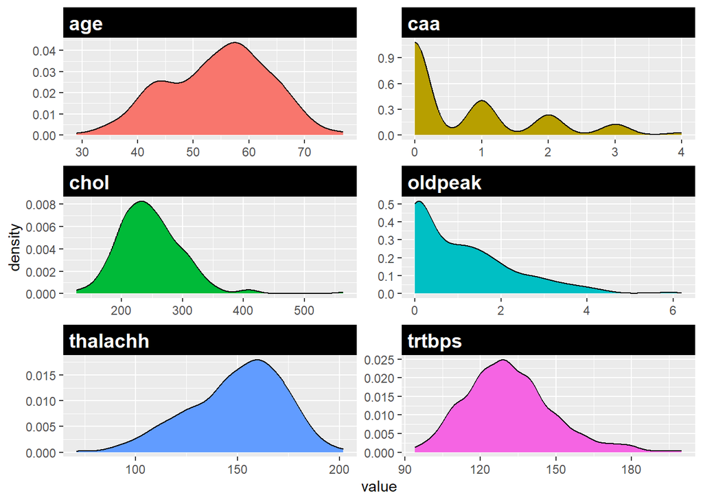

Ahora, analicemos los valores atípicos, para lo cual emplearemos el diagrama de cajas o boxplot:

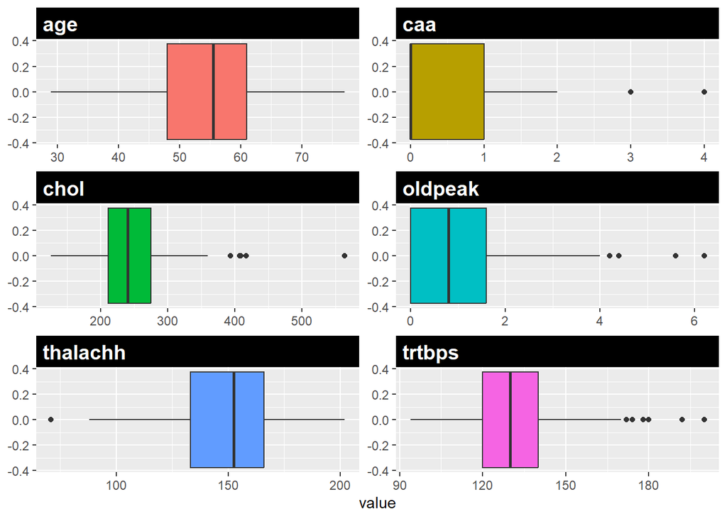

- **caa**: La variable caa posee dos valores atípicos $3$ y $4$, no obstante en la definición de esta variable se especifica que su dominio es $(0-3)$, por lo que el único valor atípico es $4$. Vamos a reemplazar estos valores atípicos por el valor máximo de esta variable que es $3$.
- Para las variables **chol**, **oldpeak** y **trtbps** vamos a reemplazar los valores atípicos por la mediana de cada una de las variables, debido la media está sesgada por los valores atípicos.

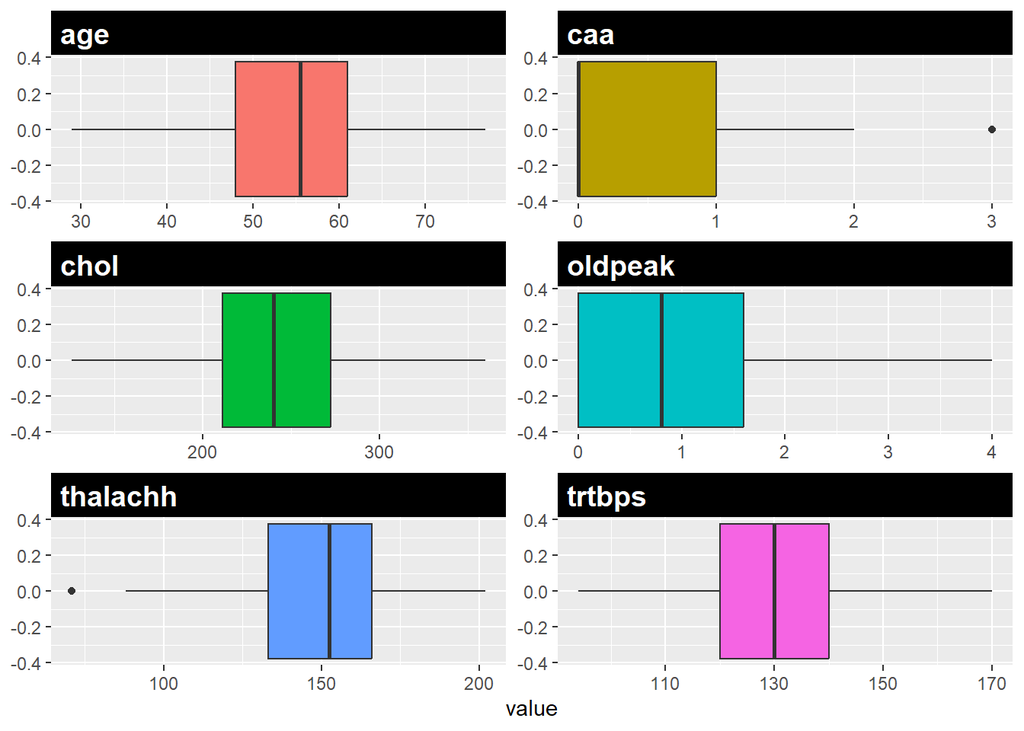

```r
data %>% select(is.numeric) %>% gather(metric, value) %>% ggplot(aes(value, fill = metric)) +
                                geom_boxplot(show.legend = FALSE) + facet_wrap(~ metric, scales = "free", ncol = 2) +
                                theme(strip.text=element_text(face='bold', size=14, hjust=0, color='white'),
                                strip.background=element_rect(fill='black'))
```

### 3.2.2 Variables categóricas

Para las variables categóricas vamos a presentar su diagrama de frecuencias:

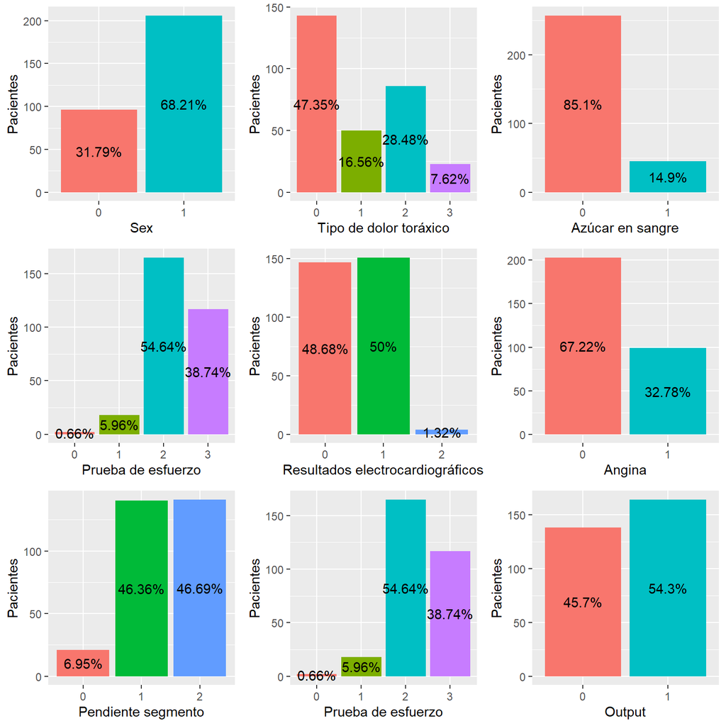

Se tienen las siguientes observaciones:

```r
data<- data %>% mutate(thall = if_else(thall == "0", "2", thall) )
```

- **output**: El $45.7\%$ de los pacientes tiene menos probabilidades de sufrir un ataque al corarón, mientras que el $54.3\%$ de los pacientes tiene más probabilidades de sufrir un ataque al corazón.

# 4 Análisis de datos

Aplicando el análisis de datos podemos obtener información relevante sobre los factores que pueden influir en los ataques cardíacos. Al explorar y examinar los datos, podemos identificar patrones, relaciones y características relevantes que ayudarán a comprender mejor los riesgos y tomar medidas preventivas adecuadas para la salud cardiovascular de los pacientes, lo que potencialmente puede salvar vidas y mejorar la calidad de vida de las personas.

Además, se realizará un análisis de las variables categóricas “sex”, “cp”, “thall”, “restecg”, “exng”, “slp” y “thall” para determinar si existen diferencias significativas entre los grupos definidos por “output”. Se presentarán diagramas de frecuencias para visualizar el comportamiento de estas variables en relación con “output” y se realizarán pruebas estadísticas, como el test de chi-cuadrado y el análisis de frecuencias relativas, para identificar posibles asociaciones o diferencias entre los grupos.

Previo a aplicar los análisis mencionados, es importar validar las hipótesis de los mismos, tales como normalidad y homogeneidad de las varianzas.

## 4.1 Correlaciones

En primer lugar, para determinar el tipo de prueba para analizar las correlaciones de las variables numéricas vamos a verificar si nuestras variables tienen o no distribuciones normales. Para ello, emplearemos la prueba de Shapiro-Wilk, la cual contrasta las siguientes hipótesis:

$$\begin{cases} H_0: \text{Los datos
siguen distribución normal.} \\ H_1: \text{Los datos no siguen una
ditribución normal.} \; \end{cases}$$

**age**

```
##
##  Shapiro-Wilk normality test
##
## data:  data$age
## W = 0.98664, p-value = 0.006745
```

Considerando un nivel de confianza $\alpha = 0.05$ se rechaza la hipótesis nula, y podemos concluir que los datos no siguen una distribución normal.

**trtbps**

```
##
##  Shapiro-Wilk normality test
##
## data:  data$trtbps
## W = 0.98394, p-value = 0.001851
```

Considerando un nivel de confianza $\alpha = 0.05$ se rechaza la hipótesis nula, y podemos concluir que los datos no siguen una distribución normal.

**chol**

```
##
##  Shapiro-Wilk normality test
##
## data:  data$chol
## W = 0.99333, p-value = 0.2007
```

Considerando un nivel de confianza $\alpha = 0.05$ no se rechaza la hipótesis nula, y podemos concluir que los datos siguen una distribución normal.

**thalachh**:

```
##
##  Shapiro-Wilk normality test
##
## data:  data$thalachh
## W = 0.97679, p-value = 8.268e-05
```

Para un nivel de confianza $\alpha = 0.05$ se rechaza la hipótesis nula, y podemos concluir que los datos no siguen una distribución normal.

**oldpeak**:

```
##
##  Shapiro-Wilk normality test
##
## data:  data$oldpeak
## W = 0.85925, p-value = 6.266e-16
```

De igual forma si se considera un nivel de confianza $\alpha = 0.05$ se rechaza la hipótesis nula, y podemos concluir que los datos no siguen una distribución normal.

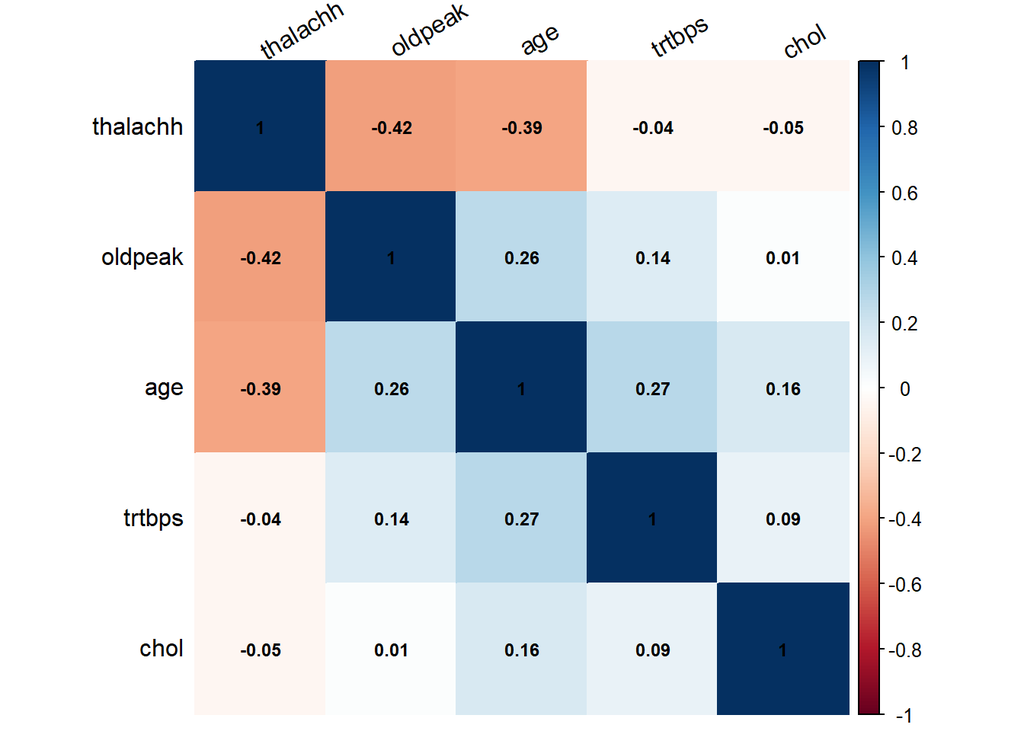

No observamos fuertes correlaciones positivas o negativas entre las variables, no obtante, vamos a aplicar pruebas de hipótesis para determinar si la correlación es significativamente distinta de cero. Para lo cual, emplearemos la prueba de Spearman, la cual contrasta las hipótesis:

$$\begin{cases} H_0: \text{Las
variables}\; X\; \text{y} \; Z\; \text{son independientes}\\ H_1:
\text{Las variables}\; X\; \text{y} \; Z\; \text{no son
independientes} \end{cases}$$
**thalachh vs oldpeak**

```
##
##  Spearman's rank correlation rho
##
## data:  data$thalachh and data$oldpeak
## S = 6506261, p-value = 3.723e-14
## alternative hypothesis: true rho is not equal to 0
## sample estimates:
##       rho
## -0.417316
```

Para un nivel de confianza $\alpha = 0.05$, se rechaza la hipótesis nula y podemos concluir que la correlación entre las variables **thalachh** y **oldpeak** es de $-0.417$, no obstante, este no es un valor elevado.

**thalachh vs age**

También aplicaremos la prueba a las variables **thalachh** y **age*:

```
##
##  Spearman's rank correlation rho
##
## data:  data$thalachh and data$age
## S = 6396719, p-value = 1.271e-12
## alternative hypothesis: true rho is not equal to 0
## sample estimates:
##        rho
## -0.3934534
```

De igual forma, considerando un nivel de confianza $\alpha = 0.05$, se rechaza la hipótesis nula y podemos concluir que la correlación entre las variables **thalachh** y **age** es de $-0.393$, el cual no es un valor elevado.

**thalachh vs trtbps**

```
##
##  Spearman's rank correlation rho
##
## data:  data$thalachh and data$trtbps
## S = 4784894, p-value = 0.4636
## alternative hypothesis: true rho is not equal to 0
## sample estimates:
##         rho
## -0.04233545
```

Con un nivel de confianza $\alpha = 0.05$, dado que $p-valor > \alpha$, no se rechaza la hipótesis nula y podemos concluir que las variables **thalachh** y **trtbps** son independientes.

**thalachh vs chol**

```
##
##  Spearman's rank correlation rho
##
## data:  data$thalachh and data$chol
## S = 4808107, p-value = 0.4119
## alternative hypothesis: true rho is not equal to 0
## sample estimates:
##         rho
## -0.04739214
```

## 4.2 Comparación entre grupos

### 4.2.1 Variables numéricas

En primer, lugar vamos a estudiar gráficamente el comportamiento de las variables **age**, **trtbps**, **thalachh** y **oldpeak** con respecto a la variable **output**, para lo cual, vamos a diagramas de cajas:

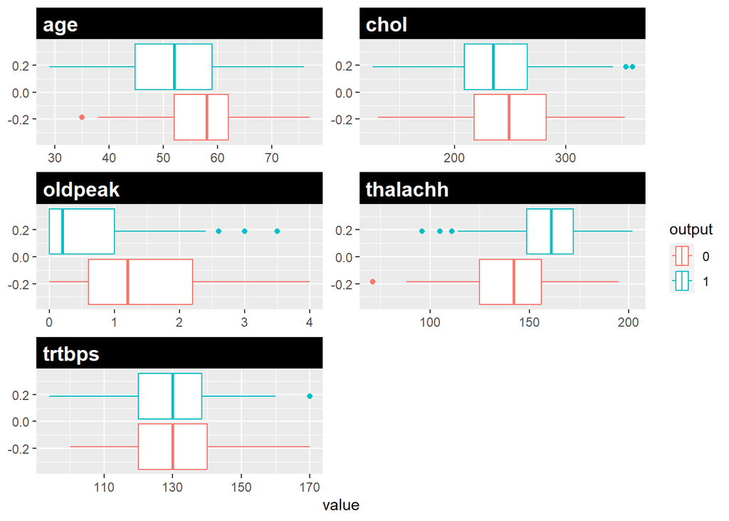

Podemos notar que existen diferencias significativas de las variables **age**, **chol**, **oldpeak** y **thalachh** con respecto a la variable **ouput**. Vamos a comprobar estas hipótesis aplicando pruebas estadísticas.

Para ello, en primer lugar, como pudimos observar anteriormente solamente la variable **chol** sigue una distribución normal por lo que vamos a aplicar la transformación de Box - Cox para el resto de variables:

De este modo, aplicamos la prueba de Shapiro-Wilk a las variables transformadas:

**age**

```
##
##  Shapiro-Wilk normality test
##
## data:  dataT$ageT
## W = 0.98848, p-value = 0.01691
```

Considerando un nivel de confianza $\alpha = 0.05$ se rechaza la hipótesis nula, y podemos concluir que los datos no siguen una distribución normal.

**trtbps**

```
##
##  Shapiro-Wilk normality test
##
## data:  dataT$trtbpsT
## W = 0.98419, p-value = 0.002079
```

Considerando un nivel de confianza $\alpha = 0.05$ se rechaza la hipótesis nula, y podemos concluir que los datos no siguen una distribución normal.

**thalachh**:

```
##
##  Shapiro-Wilk normality test
##
## data:  dataT$thalachhT
## W = 0.99174, p-value = 0.0901
```

Para un nivel de confianza $\alpha = 0.05$, dado que $p-valor > \alpha$, no se rechaza la hipótesis nula, y podemos concluir que los datos siguen una distribución normal.

**oldpeak**:

```
##
##  Shapiro-Wilk normality test
##
## data:  dataT$oldpeakT
## W = 0.78649, p-value < 2.2e-16
```

Considerando un nivel de confianza $\alpha = 0.05$ se rechaza la hipótesis nula, y podemos concluir que los datos no siguen una distribución normal.

De este modo, vamos a aplicar la prueba de homocedasticidad a la variable **chol** y a la variable transformada **thalachh**:

**chol**:

```
## Levene's Test for Homogeneity of Variance (center = median)
##        Df F value Pr(>F)
## group   1  1.0697 0.3018
##       300
```

```
##
##  Welch Two Sample t-test
##
## data:  chol by output
## t = 1.9412, df = 285.7, p-value = 0.05321
## alternative hypothesis: true difference in means between group 0 and group 1 is not equal to 0
## 95 percent confidence interval:
##  -0.1394118 20.1472768
## sample estimates:
## mean in group 0 mean in group 1
##        248.6594        238.6555
```

En este caso, el $p-valor$ es mayor al nivel de significancia $\alpha = 0.05$. Por lo cual, no se rechaza la hipótesis nula, es decir, no se observan diferencias significativas entre el colesterol de las personas menos propensas a sufrir un ataque cardíaco y las personas más propensas a sufrir un ataque cardíaco.

**thalachhT**:

```
## Levene's Test for Homogeneity of Variance (center = median)
##        Df F value Pr(>F)
## group   1  0.9923   0.32
##       300
```

```
##
##  Welch Two Sample t-test
##
## data:  thalachhT by output
## t = -8.034, df = 285.33, p-value = 2.507e-14
## alternative hypothesis: true difference in means between group 0 and group 1 is not equal to 0
## 95 percent confidence interval:
##  -3480.782 -2110.851
## sample estimates:
## mean in group 0 mean in group 1
##        9924.245       12720.062
```

En este caso, el $p-valor$ es menor al nivel de significancia $\alpha = 0.05$. Por lo cual, se rechaza la hipótesis nula, es decir, se observan diferencias significativas de la frecuencia máxima alcanzada entre entre las personas menos propensas a sufrir un ataque cardíaco y las personas más propensas a sufrir un ataque cardíaco. De hecho, podemos ver que el promedio estimado del grupo de personas menos propensas es menor al grupo de las personas más propensas.

Para el resto de variables numéricas vamos a trabajar con las variables originales, dado que las tranformaciones de Box y Cox de estas variables no cumplieron el supuesto de normalidad y aplicaremos la prueba de Wilcoxon:

**age**

```
##
##  Wilcoxon rank sum test with continuity correction
##
## data:  age by output
## W = 14394, p-value = 4.626e-05
## alternative hypothesis: true location shift is not equal to 0
```

En este caso el $p-valor$ es menor al nivel de significancia $\alpha = 0.05$, por lo cual, sí se observan diferencias estadísticamente significativas en la edad de los pacientes con respecto a la variable **output**.

**chol**

```
##
##  Wilcoxon rank sum test with continuity correction
##
## data:  chol by output
## W = 12944, p-value = 0.03127
## alternative hypothesis: true location shift is not equal to 0
```

El $p-valor$ es menor al nivel de significancia $\alpha = 0.05$, por lo cual, sí se observan diferencias estadísticamente significativas en el nivel del colesterol entre las pesonas menos probables y más probables a sufir un ataque al corazón.

**trtbps**

```
##
##  Wilcoxon rank sum test with continuity correction
##
## data:  trtbps by output
## W = 12694, p-value = 0.06744
## alternative hypothesis: true location shift is not equal to 0
```

En este caso el $p-valor$ es mayor al nivel de significancia $\alpha = 0.05$, por lo cual, no se observan diferencias estadísticamente significativas en la presión arterial entre los pacientes más propensos y menos propensos a sufrir ataques cardíacos.

**oldpeakT**

```
##
##  Wilcoxon rank sum test with continuity correction
##
## data:  oldpeak by output
## W = 16620, p-value = 9.191e-13
## alternative hypothesis: true location shift is not equal to 0
```

En este caso el $p-valor$ es menor al nivel de significancia $\alpha = 0.05$, por lo cual, sí se observan diferencias estadísticamente significativas en la depresión del segmento ST de los pacientes más probables y menos probables a sufir ataques cardíacos.

### 4.2.2 Variables categóricas

En esta sección vamos a determinar si existen diferencias significativas de las variables categóricas **sex**, **cp**, **thall**, **restecg**, **exng**, **slp**, **thall** entre los grupos definidos por la variable categórica **output**. En primer lugar, vamos a presentar diagramas de frecuencias de cada una de estas variables con respecto a la variable **output**, lo cual nos permitirá formar una idea sobre el comportamiento de estas variables.

Para ello, vamos a emplear el test $\chi^2$, el cual plantea la siguiente prueba de hipótesis:

$$\begin{cases} H_0: \text{La variable}\;
X\; \text{es independiente a la variable}\; Y. \\ H_1: \text{Las
variables}\; X\; \text{y} \; Y\; \text{están asocidadas}. \;
\end{cases}$$

**sex** y **output**:

```
##
##             0         1
##   0 0.2500000 0.7500000
##   1 0.5533981 0.4466019
```

Con la prueba $\chi^2$ se obtienen los siguientes resultados:

```r
outputsex<- table(data$sex, data$output)
chisq.test(outputsex)
```

```
##
##  Pearson's Chi-squared test with Yates' continuity correction
##
## data:  outputsex
## X-squared = 23.084, df = 1, p-value = 1.551e-06
```

Considerando un nivel de significancia del $\alpha = 0.05$, dado que $p-valor < \alpha$, podemos rechazar la hipótesis nula y concluir que existe una asociación significativa entre las variables **sex** y **output**. Es decir, podemos afirmar que la distribución de género difiere significativamente entre los grupos de **output**.

**cp** y **output**

```r
prop.table(table(data$cp, data$output), margin = 1)
```

```
##
##             0         1
##   0 0.7272727 0.2727273
##   1 0.1800000 0.8200000
##   2 0.2093023 0.7906977
##   3 0.3043478 0.6956522
```

Aplicado la prueba $\chi^2$, tenemos que:

```r
outputcp<- table(data$cp, data$output)
chisq.test(outputcp)
```

```
##
##  Pearson's Chi-squared test
##
## data:  outputcp
## X-squared = 80.979, df = 3, p-value < 2.2e-16
```

Para un nivel de significancia del $\alpha = 0.05$, dado que $p-valor < \alpha$, podemos rechazar la hipótesis nula y concluir que existe una asociación significativa entre las variables **cp** y **output**. Es decir, podemos afirmar que la distribución de la variable **cp** (tipo de dolor toráxico) difiere significativamente entre los grupos de **output**.

**thall** y **output**

```r
prop.table(table(data$thall, data$output), margin = 1)
```

```
##
##             0         1
##   1 0.6666667 0.3333333
##   2 0.2215569 0.7784431
##   3 0.7606838 0.2393162
```

Con la prueba $\chi^2$ se obtienen los siguientes resultados:

```
##
##  Pearson's Chi-squared test
##
## data:  outputthall
## X-squared = 83.978, df = 2, p-value < 2.2e-16
```

Para un nivel de significancia del $\alpha = 0.05$, dado que $p-valor < \alpha$, podemos rechazar la hipótesis nula y concluir que existe una asociación significativa entre las variables **thall** y **output**. Es decir, podemos afirmar que la distribución de la variable **thall** (resultados de prueba de esfuerzo con talio) difiere significativamente entre los grupos de **output**.

**restecg** y **output**

```
##
##             0         1
##   0 0.5374150 0.4625850
##   1 0.3708609 0.6291391
##   2 0.7500000 0.2500000
```

La prueba $\chi^2$ nos indica los siguientes resultados:

```
##
##  Pearson's Chi-squared test
##
## data:  outputrestecg
## X-squared = 9.7297, df = 2, p-value = 0.007713
```

Para un nivel de significancia del $\alpha = 0.05$, dado que $p-valor < \alpha$, podemos rechazar la hipótesis nula y concluir que existe una asociación significativa entre las variables **restecg** y **output**. Es decir, podemos afirmar que la distribución de la variable **restecg** (resultados electrocardiográficos en reposo) difiere significativamente entre los grupos de **output**.

**exng** y **output**

```
##
##             0         1
##   0 0.3054187 0.6945813
##   1 0.7676768 0.2323232
```

- Si el paciente posee angina la tasa de salud ($76.77\%$) es mayor a la tasa de sufrir un ataque cardíaco ($23.23\%$).

Con la prueba $\chi^2$, obtenemos los siguientes resultados:

```
##
##  Pearson's Chi-squared test with Yates' continuity correction
##
## data:  outputexng
## X-squared = 55.456, df = 1, p-value = 9.556e-14
```

Para un nivel de significancia del $\alpha = 0.05$, dado que $p-valor < \alpha$, podemos rechazar la hipótesis nula y concluir que existe una asociación significativa entre las variables **exng** y **output**. Es decir, podemos afirmar que la distribución de la variable **exng** (angina producida por ejercicio) difiere significativamente entre los grupos de **output**.

**slp** y **output**

```
##
##             0         1
##   0 0.5714286 0.4285714
##   1 0.6500000 0.3500000
##   2 0.2482270 0.7517730
```

La prueba $\chi^2$ no permite obtener los siguientes resultados:

```
##
##  Pearson's Chi-squared test
##
## data:  outputslp
## X-squared = 46.889, df = 2, p-value = 6.578e-11
```

Si consideramos un nivel de significancia del $\alpha = 0.05$, dado que $p-valor < \alpha$, podemos rechazar la hipótesis nula y concluir que existe una asociación significativa entre las variables **slp** y **output**. Es decir, podemos afirmar que la distribución de la variable **slp** (Pendiente de un segmento de electrocardiograma) difiere significativamente entre los grupos de **output**.

**fbs** y **output**

```
##
##             0         1
##   0 0.4513619 0.5486381
##   1 0.4888889 0.5111111
```

- En ambas categorías la tasa de salud es menor a la tasa de enfermedad.

Aplicando la prueba $\chi^2$, se obtiene que:

```
##
##  Pearson's Chi-squared test with Yates' continuity correction
##
## data:  outputfbs
## X-squared = 0.092408, df = 1, p-value = 0.7611
```

Si consideramos un nivel de significancia del $\alpha = 0.05$, dado que $p-valor > \alpha$, no podemos rechazar la hipótesis nula, por lo cual, no existe una asociación significativa entre las variable **fbs** y **output**.

## 4.3 Regresión logística

En el apartado anterior realizamos un análisis bivariado entre las variables numéricas y las variables categóricas con respecto a la variable **ouput**, por lo cual, en esta sección vamos a presentar un modelo de clasificación con la intención de predecir la probabilidad de que una persona sea más propensa a sufrir un ataque cardíaco, para ello, vamos a utilizar una regresión logística.

En primer lugar, vamos a divir el conjunto de datos de modo que el $80\%$ corresponda a la muestra de entrenamiento y el $20\%$ a la muestra de validación, para ello, emplearemos la *librería caret* y la *función createDataPartition()*.

Verificamos que se mantenga la misma proporción de pacientes propensos y menos propensos a sufrir un ataque cardíaco en ambas muestras:

| output | n | Percent |
| --- | --- | --- |
| 0 | 111 | 45.68 |
| 1 | 132 | 54.32 |

Mientras que para la muestra de validación se tiene que:

| output | n | Percent |
| --- | --- | --- |
| 0 | 27 | 45.76 |
| 1 | 32 | 54.24 |

Por lo cual, podemos notar que la variable **output** se encuentra distribuída proporcionalmente en ambas muestras.

### 4.3.1 Selección de variables

En los modelos logit, la prueba para contrastar las hipótesis si los coeficientes son diferentes de cero $(\beta_i\neq0)$ es la prueba de Wald.

Consideremos:

$$\begin{align*}
H_0: \hat{\beta}_j & = \beta_{j0}, \\
H_a: \hat{\beta}_j & \neq \beta_{j0}.
\end{align*}$$

Bajo la hipótesis nula, el estadístico de Wald sigue una distribución $\chi^2$, y se define por:
$$T = \frac{(\hat{\beta}_j-\beta_{j0})^{2}}{V[\hat{\beta}_j]}$$

Para seleccionar los predictores que deben formar parte del modelo, emplearemos el método backward, este método primero calcula el modelo con todas las variables disponibles, luego se excluyen las variables una a una buscando una mejoría para finalmente eliminar la peor variable. Este método permite evaluar cada variable en presencia de las otras.

Para seleccionar los parámetros del modelo logit emplearemos el criterio de Akaike, que propone estudiar el problema de la identificación desde la perspectiva de la teoría de decisión estadística, que consiste en elegir como función de pérdida (o criterio de especificación) el AIC (Akaike Information Criterion) mínimo. Este valor se calcula por:

$$AIC = -2ln( \text{ máxima verosimilitud} ) + 2(\text{ no. de
parámetros independientemente ajustados}).$$

Previo a aplicar el modelo, vamos a transformar las variables categóricas a dummy’s, para ello, vamos a emplear la *librería fastDummies*:

```r
library(fastDummies)
training<- training %>% dummy_cols(select_columns = c("sex","cp","fbs","restecg","exng","slp","thall" ), remove_selected_columns = T )
```

Aplicamos el modelo con todas las variables y luego consideramos el método backward para seleccionar las variables que formarán parte del modelo final.

```
##
## Call:
## glm(formula = output ~ ., family = "binomial", data = training)
##
## Deviance Residuals:
##     Min       1Q   Median       3Q      Max
## -2.7784  -0.3559   0.1571   0.5363   2.3950
##
## Coefficients: (7 not defined because of singularities)
##              Estimate Std. Error z value Pr(>|z|)
## (Intercept)  0.808359   4.092423   0.198 0.843416
## age          0.009303   0.025993   0.358 0.720419
## trtbps      -0.016871   0.014976  -1.126 0.259963
## chol        -0.007389   0.005502  -1.343 0.179311
## thalachh     0.021068   0.011451   1.840 0.065795 .
## oldpeak     -0.656341   0.260801  -2.517 0.011848 *
## caa         -0.910652   0.250324  -3.638 0.000275 ***
## sex_0        1.416172   0.562641   2.517 0.011836 *
## sex_1              NA         NA      NA       NA
## cp_0        -1.687161   0.749041  -2.252 0.024295 *
## cp_1        -0.756450   0.855150  -0.885 0.376382
## cp_2         0.109777   0.749317   0.147 0.883525
## cp_3               NA         NA      NA       NA
## fbs_0       -0.078895   0.601051  -0.131 0.895569
## fbs_1              NA         NA      NA       NA
## restecg_0    0.226174   2.307804   0.098 0.921929
## restecg_1    1.122205   2.303237   0.487 0.626096
## restecg_2          NA         NA      NA       NA
## exng_0       0.663503   0.474974   1.397 0.162436
## exng_1             NA         NA      NA       NA
## slp_0       -0.496047   1.124016  -0.441 0.658983
## slp_1       -0.636832   0.514912  -1.237 0.216169
## slp_2              NA         NA      NA       NA
## thall_1      1.099223   0.827909   1.328 0.184274
## thall_2      1.191371   0.456319   2.611 0.009032 **
## thall_3            NA         NA      NA       NA
## ---
## Signif. codes:  0 '***' 0.001 '**' 0.01 '*' 0.05 '.' 0.1 ' ' 1
##
## (Dispersion parameter for binomial family taken to be 1)
##
##     Null deviance: 335.05  on 242  degrees of freedom
## Residual deviance: 163.25  on 224  degrees of freedom
## AIC: 201.25
##
## Number of Fisher Scoring iterations: 6
```

Se puede encontrar variables no significativas cuyo p-valor es mayor a $0.05$, por lo tanto, hay que estimar un nuevo modelo.

```r
step(logit, direction = "backward")
```

De este modo, consideramos el siguiente modelo:

```
##
## Call:
## glm(formula = output ~ chol + thalachh + oldpeak + caa + sex_0 +
##     cp_0 + restecg_1 + thall_2, family = "binomial", data = training)
##
## Deviance Residuals:
##     Min       1Q   Median       3Q      Max
## -2.4670  -0.3981   0.1800   0.5297   2.3794
##
## Coefficients:
##              Estimate Std. Error z value Pr(>|z|)
## (Intercept) -0.658266   1.818014  -0.362 0.717293
## chol        -0.009110   0.005012  -1.818 0.069133 .
## thalachh     0.024201   0.009605   2.520 0.011745 *
## oldpeak     -0.750708   0.206308  -3.639 0.000274 ***
## caa         -0.775425   0.220773  -3.512 0.000444 ***
## sex_0        1.154603   0.492382   2.345 0.019030 *
## cp_0        -1.647800   0.408360  -4.035 5.46e-05 ***
## restecg_1    0.975578   0.400211   2.438 0.014783 *
## thall_2      1.212180   0.420171   2.885 0.003914 **
## ---
## Signif. codes:  0 '***' 0.001 '**' 0.01 '*' 0.05 '.' 0.1 ' ' 1
##
## (Dispersion parameter for binomial family taken to be 1)
##
##     Null deviance: 335.05  on 242  degrees of freedom
## Residual deviance: 170.50  on 234  degrees of freedom
## AIC: 188.5
##
## Number of Fisher Scoring iterations: 6
```

```r
odds<- exp(coefficients(logitFinal))
odds
```

```
## (Intercept)        chol    thalachh     oldpeak         caa       sex_0
##   0.5177486   0.9909313   1.0244964   0.4720322   0.4605078   3.1727632
##        cp_0   restecg_1     thall_2
##   0.1924728   2.6527008   3.3608046
```

Para determinar el punto de corte y clasificar a los pacientes vamos a determinar la medida de Kolmogorov - Smirnov, de este, modo presentamos el gráfico de las distribuciones acumuladas de la razón de verdaderos positivos y la distribución de falsos positivos.

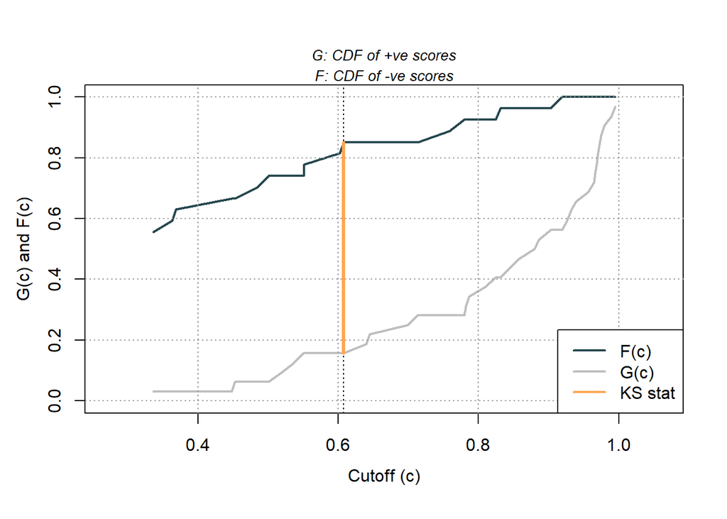

De este modo, el valor del $KS$ es 0.6956019, el cual se alcanza en 0.6077056. Por lo cual, vamos a clasificar como pacientes propensos a sufrir un ataque cardíaco aquellos pacientes cuya probabilidad sea mayor a 0.6077056. De este modo, presentamos la matriz de confusión:

```
## Confusion Matrix and Statistics
##
##           Reference
## Prediction  0  1
##          0 23  6
##          1  4 26
##
##                Accuracy : 0.8305
##                  95% CI : (0.7103, 0.9156)
##     No Information Rate : 0.5424
##     P-Value [Acc > NIR] : 3.14e-06
##
##                   Kappa : 0.6605
##
##  Mcnemar's Test P-Value : 0.7518
##
##             Sensitivity : 0.8125
##             Specificity : 0.8519
##          Pos Pred Value : 0.8667
##          Neg Pred Value : 0.7931
##              Prevalence : 0.5424
##          Detection Rate : 0.4407
##    Detection Prevalence : 0.5085
##       Balanced Accuracy : 0.8322
##
##        'Positive' Class : 1
##
```

De este modo, el modelo tiene una exactitud del $83.05\%$`, una precisión de $86.67\%$ y un $F_1-score$ del $83.87\%$.

Ahora, vamos a calcular el valor del área bajo la curva $AUC$, para ello, consideremos la curva ROC:

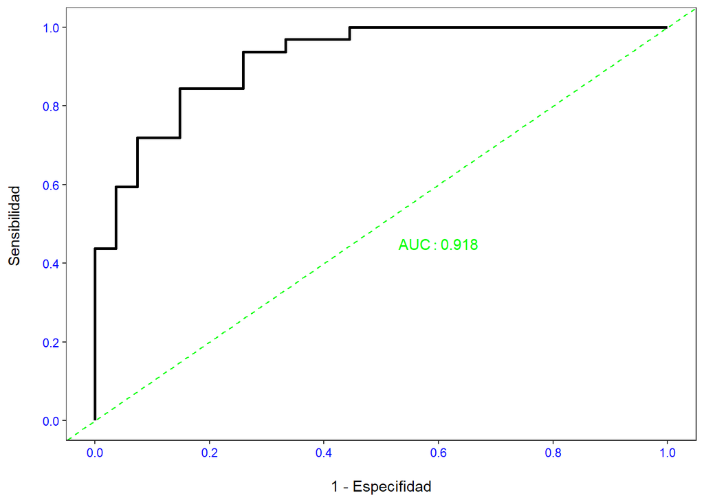

Con lo cual, obtenemos un valor de $AUC = 0.92$.

Finalmente, para detectar la multicolinealidad emplearemos el **Factor de Inflación de la Varianza Generalizado (GVIF)** de los parámetros estimados, el cual proporciona un índice que mide hasta que punto la varianza de un coeficiente de regresión estimado se incrementa a causa de la colinealidad; Los valores de los GVIF calculados de cada variable no deben ser mayores a 4

```
##      chol  thalachh   oldpeak       caa     sex_0      cp_0 restecg_1   thall_2
##  1.146483  1.147110  1.053059  1.024546  1.198328  1.102594  1.060397  1.151725
```

Podemos notar que para ninguna variable el valor del $GVIF$ es superior a $4$, por lo cual, podemos concluir que no existen problemas de multicolinealidad.

# 5 Representación de los resultados a partir de tablas y gráficas.

A lo largo de la práctica, se utilizaron varias representaciones gráficas y tablas para mostrar los resultados. A continuación, se muestran algunos ejemplos de las representaciones utilizadas:

- Representación gráfica de la distribución de variables numéricas: Se utilizaron gráficos de densidad y diagramas de caja para representar la distribución de las variables numéricas (age, trtbps, chol, thalachh, oldpeak) en relación a la variable “output”. Estos gráficos permiten visualizar la forma de la distribución, los valores atípicos y las diferencias entre los grupos.
- Representación gráfica de variables categóricas: Se utilizaron gráficos de barras para representar la frecuencia de las variables categóricas (sex, cp, fbs, restecg, exng, slp, thall, output). Estos gráficos permiten comparar las proporciones de diferentes categorías y observar posibles patrones o tendencias.
- Tabla de correlaciones: Se calculó la matriz de correlaciones (método de Spearman) entre las variables numéricas (age, trtbps, chol, thalachh, oldpeak) y se mostró en una tabla. Esta tabla permite identificar las relaciones de correlación entre las variables.
- Gráfico de cajas para variables numéricas y output: Se utilizó un gráfico de cajas para representar la distribución de las variables numéricas (age, trtbps, chol, thalachh, oldpeak) en relación a la variable “output”. Este gráfico muestra las diferencias en las distribuciones entre los grupos de “output”.
- Gráfico ROC (Receiver Operating Characteristic): Se utilizó un gráfico ROC para evaluar el rendimiento del modelo predictivo. Este gráfico muestra la sensibilidad frente a la especificidad del modelo a diferentes puntos de corte y calcula el área bajo la curva (AUC), que indica la capacidad de discriminación del modelo.

# 6 Resolución del problema

A partir de los resultados obtenidos en el análisis estadístico y la evaluación del modelo de regresión logística, podemos llegar a las siguientes conclusiones:

# 7 Código

Durante el desarrollo del ejercicio, se empleó el lenguaje de programación R, el cual se encuentra alojado en un repositorio de GitHub. Se utilizaron diversas herramientas y técnicas para abordar los siguientes elementos:

Descripción del dataset: Se realizó una descripción detallada de los datos utilizados en el análisis, incluyendo la naturaleza de las variables, la estructura de los datos y la distribución de los valores.

Limpieza de datos: Se realizaron tareas de limpieza y preprocesamiento de los datos para garantizar su calidad y adecuación para el análisis. Esto incluyó el manejo de valores faltantes, la corrección de errores y la transformación de variables si fuera necesario.

Variables numéricas: Se llevaron a cabo técnicas como el imputado de valores faltantes, la detección y tratamiento de outliers, y la normalización o estandarización de variables si fuera requerido.

Variables categóricas: Se realizó el manejo de variables categóricas, incluyendo la codificación de variables categóricas en variables numéricas utilizando técnicas como la codificación one-hot o la codificación ordinal.

Correlaciones: Se exploraron las correlaciones entre las variables para identificar posibles relaciones o dependencias entre ellas.

Comparación entre grupos: Se realizaron comparaciones entre grupos de datos utilizando técnicas estadísticas adecuadas. Esto incluyó la comparación de variables numéricas entre diferentes grupos utilizando pruebas de hipótesis o análisis de varianza, y la comparación de variables categóricas utilizando tablas de contingencia y pruebas de chi-cuadrado.

Variables numéricas: Se compararon las distribuciones de variables numéricas entre diferentes grupos para evaluar posibles diferencias estadísticamente significativas.

Variables categóricas: Se compararon las frecuencias de las categorías de variables categóricas entre diferentes grupos para determinar si existían diferencias significativas.

Regresión logística: Se aplicó el modelo de regresión logística para predecir la probabilidad de que una persona sea propensa a sufrir un ataque cardíaco. Se realizaron técnicas de selección de variables para identificar las variables más relevantes en el modelo.

Conclusiones: A partir de los resultados obtenidos, se elaboraron conclusiones sobre el análisis realizado. Estas conclusiones pueden incluir hallazgos importantes, relaciones identificadas entre variables, el rendimiento del modelo de regresión logística y su capacidad para predecir la probabilidad de ataques cardíacos, entre otros aspectos relevantes.

# 8 Vídeo

[Enlace](https://drive.google.com/drive/folders/1nm67WNiMnT7WIBGh5kqJjXXaBpQsYaqV?usp=sharing)

**Contribuciones**

| **Contribuciones** | **Firma Integrantes** |
| --- | --- |
| Investigación previa | WGGB, OADT |
| Redacción de las respuestas | WGGB, OADT |
| Desarrollo del código | WGGB, OADT |
| Participación en el vídeo | WGGB, OADT |